# SH Data Preparation

# Assess missingness

Summaries exclude the two study participants (PtIDs 194 and 183) that do not have any demographic data. They will not be included in the analysis.

## Demographics, lifestyle, and diabetes management

### Sex

| Gender | Overall | Case | Control |
| --- | --- | --- | --- |
| F | 95 | 51 | 44 |
| M | 106 | 50 | 56 |

Sex is a complete variable; no additional cleaning.

### Race

| Race | Overall | Control | Case |
| --- | --- | --- | --- |
| American Indian/Alaskan Native | 1 | 1 | NA |
| Asian | 1 | 1 | NA |
| Black/African American | 7 | 3 | 4 |
| Unknown/not reported | 1 | NA | 1 |
| White | 191 | 95 | 96 |

PtID 157: Race is “Unknown/not reported” and ethnicity is “Hispanic or Latino”

### Ethnicity

| Ethnicity | Overall | Case | Control |
| --- | --- | --- | --- |
| Hispanic or Latino | 6 | 3 | 3 |
| Not Hispanic or Latino | 194 | 98 | 96 |
| Unknown/not reported | 1 | NA | 1 |

PtID 69: Race is white and ethnicity is Unknown/not reported

### Age

Still looking for this in the CRFs

### Disease duration

Propose defn: Age - Age dx; have age dx, still looking for age

### Education

| EduLevel | Overall | Case | Control |
| --- | --- | --- | --- |
| 11th Grade | 1 | 1 | NA |
| 12th Grade - no diploma | 1 | 1 | NA |
| 7th or 8th Grade | 1 | 1 | NA |
| 9th Grade | 1 | NA | 1 |
| Associate Degree | 17 | 10 | 7 |
| Bachelor's Degree | 64 | 30 | 34 |
| Doctorate Degree | 8 | 4 | 4 |
| High school graduate/diploma/GED | 21 | 11 | 10 |
| Master's Degree | 33 | 17 | 16 |
| Professional Degree | 9 | 6 | 3 |

[output cut: 2 more lines]

| EduLevelNoAns | Overall | Case | Control |
| --- | --- | --- | --- |
| 1 | 2 | 1 | 1 |
| NA | 199 | 100 | 99 |

| EduLevelUnk | Overall | Case | Control |
| --- | --- | --- | --- |
| NA | 201 | 101 | 100 |

PtIDs 165 and 167: No answer to the education level question

Use the same education categories as Weinstock (2016): Less than HS or high school diploma/GED, some college/associate or bachelor degree, master/professional or doctorate degree

| EduLevel |
| --- |
| Associate Degree |
| NA |
| High school graduate/diploma/GED |
| Master's Degree |
| Some college but no degree |
| Bachelor's Degree |
| Professional Degree |
| Doctorate Degree |
| 11th Grade |
| 7th or 8th Grade |

[output cut: 2 more lines]

| educationCat | Overall | Case | Control |
| --- | --- | --- | --- |
| Advanced degree | 50 | 27 | 23 |
| College | 124 | 59 | 65 |
| HS | 25 | 14 | 11 |
| NA | 2 | 1 | 1 |

With the new education categories, PtIDs 165 and 167 continue to be missing

### Health Insurance

| InsPriv | InsGov | InsSingleService | InsNoCoverage | InsUnkown | InsNoAns | n |
| --- | --- | --- | --- | --- | --- | --- |
| 1 | 1 | 1 | NA | NA | NA | 2 |
| 1 | 1 | NA | NA | NA | NA | 66 |
| 1 | NA | 1 | NA | NA | NA | 1 |
| 1 | NA | NA | NA | NA | NA | 59 |
| NA | 1 | 1 | NA | NA | NA | 4 |
| NA | 1 | NA | NA | NA | NA | 65 |
| NA | NA | NA | 1 | NA | NA | 3 |
| NA | NA | NA | NA | NA | 1 | 1 |

PtIDs 19, 33, 1: No insurance coverage PtID 74: Did not answer

Create a new variable for has insurance/does not have insurance coverage

| anyInsurance | Overall | Case | Control |
| --- | --- | --- | --- |
| 0 | 3 | 1 | 2 |
| 1 | 197 | 99 | 98 |
| NA | 1 | 1 | NA |

With the new variable `anyInsurance`, only PtID 74 is missing.

### BMI

Construct the BMI variable from height and weight (kg/m^2). Round to 1 decimal place as is customary in reporting.

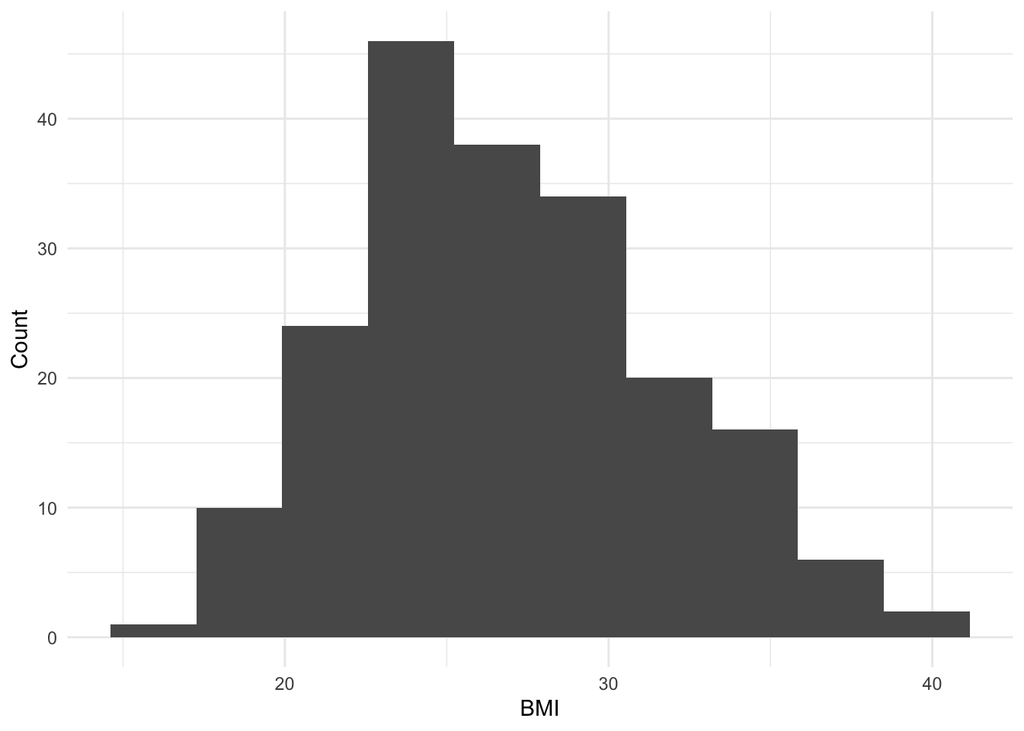

PtIDs 124, 16, 30, and 112: Incomplete data for BMI calculation (All are missing height; 112 also missing weight)

As in Weinstock (2016), we’ll also create a categorical bmi variable: underweight (BMI <18.5), normal weight (18.5 <= BMI < 25), overweight (25 <= BMI < 30), obese (BMI >= 30)

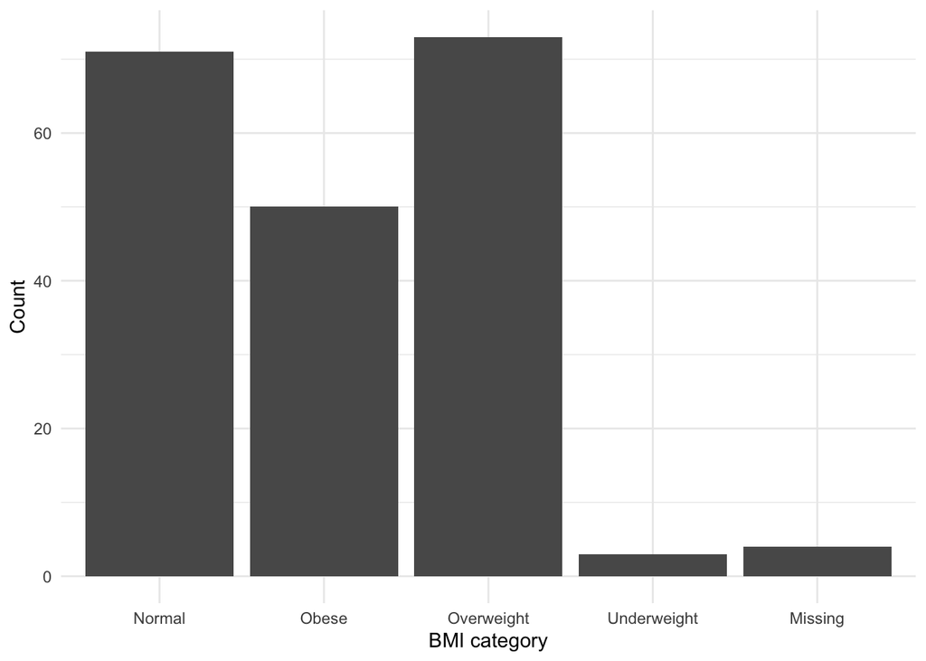

### Exercise (days/week)

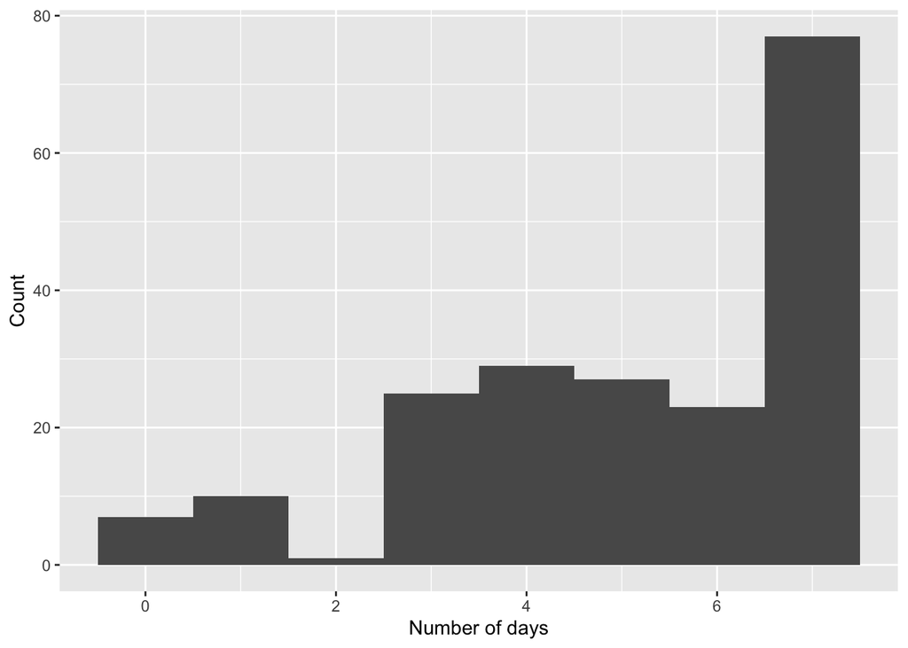

PtIDs 124 and 27: Exercise days per week is unknown

### Alcohol use

| DaysMoDrinkAlc | Overall | Case | Control |
| --- | --- | --- | --- |
| 0 | 76 | 36 | 40 |
| 1 | 14 | 9 | 5 |
| 2 | 6 | 1 | 5 |
| 3 | 7 | 4 | 3 |
| 4 | 8 | 5 | 3 |
| 5 | 11 | 5 | 6 |
| 6 | 1 | NA | 1 |
| 7 | 2 | 2 | NA |
| 8 | 7 | 3 | 4 |
| 10 | 3 | 1 | 2 |

[output cut: 10 more lines]

PtID 195: is missing Days month drink alcohol

### Lives alone

| LiveAlone | Overall | Case | Control |
| --- | --- | --- | --- |
| No | 154 | 76 | 78 |
| Yes | 47 | 25 | 22 |

This variable is complete

### Insulin pump use (Y/N)

| InsDeliveryMethod | Overall | Case | Control |
| --- | --- | --- | --- |
| Injections | 83 | 42 | 41 |
| Pump | 118 | 59 | 59 |

This variable is complete.

### Daily dose

Following Weinstock (2016) we’ll categorize units of total insulin as <40, 40-60, and >= 60

| insDoseCat | Overall | Case | Control |
| --- | --- | --- | --- |
| 40to60 | 55 | 22 | 33 |
| greater60 | 39 | 21 | 18 |
| less40 | 89 | 46 | 43 |
| NA | 18 | 12 | 6 |

PtIDs 19, 196, 164, 84, 110, 91, 24, 149, 138, 113, 124, 27, 129, 109, 1, 98, 74, 126 are missing insulin dose

### Frequency of testing glucose

| NumMeterCheckDay | Overall | Case | Control |
| --- | --- | --- | --- |
| > 19 | 1 | 1 | NA |
| 0 | 1 | 1 | NA |
| 10 | 13 | 9 | 4 |
| 13 | 1 | 1 | NA |
| 14 | 1 | 1 | NA |
| 15 | 2 | 1 | 1 |
| 2 | 6 | 1 | 5 |
| 3 | 17 | 4 | 13 |
| 4 | 45 | 21 | 24 |
| 5 | 36 | 23 | 13 |

[output cut: 4 more lines]

This variable is complete.

### HbA1c

Needs to be extracted from long form labs

### Detectable C-peptide

Waiting on definition

### Beta blocker use

Waiting on medication coding

### Abnormal creatinine

Waiting on definition

### History of DKA

## Cogntive assessments

### Montreal Cognitive Assessment

### Hopkins Verbal Learning Test - Total Recall

### Hopkins Verbal Learning Test - Delayed Recall

### Symbol Digit Modalities Test - Written

### Symbol Digit Modalities Test - Oral

### Trail Making Test - Trail A

### Train making Test - Trail B

### Grooved Pegboard Test (dominant hand)

### Geriatric depresssion scale

### Diabetes numeracy test

### Functional activities questioinnaire

### Hypoglycemia fear survey

### Preferring hypoglycemia

### Duke social support

### Frailty